# R Notebook

```r
library(tidyverse)
library(janitor)
library(modelr)
```

[output not shown]

Recap of terms:

The true positive rate: Portion of actual positive cases that are correctly identified by the classifier - prop of accepted mortgages, predicted correctly

TPR = nTP / (nTP + nFN)

The false positive rate: false alarms, the proportion of actual negative cases that are misclassified

FPR = nFP / (nFP + nTN)

Wouldn’t it be good if we could visualise the effectiveness of our classifier?

effectiveness here is meaning TPR vs FPR

well there is: ROC (Receiver Operator Characteristi) curves

Is the beep meaning there’s an enemy plane, or is it just noise (e.g. some birds)

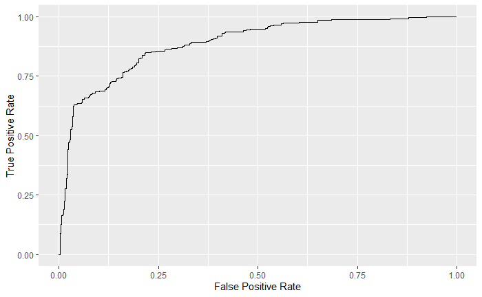

Task - 2 mins Look at the figure above and try to answer the following questions: Why are classifiers with ROC curves closer to the top-left corner said to be more effective? - High TPR and low FPR, i.e. better at detecting true positives with low levels of false positives

Which end of the curves corresponds to low threshold probability, and which to high? - low threshold at top right and high threshold at bottom left.

Ways to remember, as we decrease the threshold at which we classify, we increase the rate of false positives(of incorrectly accepting people for loans)

```r
tibble(
  threshold = roc_obj_3_terms$thresholds,
  true_positive_rate = roc_obj_3_terms$sensitivities,
  false_positive_rate = roc_obj_3_terms$specificities
)
```

| threshold | true_positive_rate | false_positive_rate |
| --- | --- | --- |
| -Inf | 1.000000000 | 0.000000000 |
| 0.008881843 | 1.000000000 | 0.001373626 |
| 0.009012745 | 1.000000000 | 0.002747253 |
| 0.009131110 | 1.000000000 | 0.004120879 |
| 0.009273563 | 1.000000000 | 0.005494505 |
| 0.009395463 | 1.000000000 | 0.006868132 |
| 0.009407056 | 1.000000000 | 0.008241758 |
| 0.009490055 | 1.000000000 | 0.009615385 |
| 0.009577092 | 1.000000000 | 0.010989011 |
| 0.009590945 | 1.000000000 | 0.012362637 |

[output cut: 983 more lines]

```r
NA
```

Task - 10 mins OK, let’s fit another classifier and add its curve to the ROC plot from earlier!

Fit a single predictor logistic regression model to the mortgage_data. We recommend tu_score as the predictor. Save the model as mortgage_1pred_model

Add the predicted probabilities from this model to mortgage_data, and save the resulting data as mortgage_data_with_1pred

Use this data to generate an an object from roc(), save the object as roc_obj_1pred

Pass your old roc_obj_3pred and new roc_obj_1pred into ggroc() [Hint check the ggroc() docs to see how to pass in multiple roc objects].

Given these ROC curves, which classifier is better?

If you have time, try another single predictor, i.e. age or employed

```r
mortgage_data_with_1pred
```

[output not shown]

“better”

What about giving a value to how good of a predictor our model is?

- AUC (area under curve) ROC curves closer to (0,1) (top left) will have a larger space under the line

Number between 0 and 1

0.5 = 50/50 classifier - we’re as good at making predictions as not

so usually our operating range for AUC is between 0.5 and 1.

```r
auc(roc_obj_3_terms)
```

```
Area under the curve: 0.8881
```

Area under the curve: 0.8881

```r
auc(roc_obj_1pred)
```

```
Area under the curve: 0.8666
```

Area under the curve: 0.8666

Based on AUC, we get a higher value for our model with 3 terms.

AUC - the are under the ROC curve, goes up to 1, higher is better, 0.5 = crappy classifier. A single number value to express how good of a classifier your model is.

- Gini

A single number value to express how good of a classifier your model is.

Gini = 2 AUC - 1

Gini will be between -1 and 1 (higher is better) 0 is a crappy classifier.

```r
gini3
```

```
[1] 0.7762151
```

```r
gini1 = 2*auc(roc_obj_1pred) - 1
gini1
```

```
[1] 0.7331327
```

Comparing Models

## Cross Validation

- splitting data before building a model into test and train

model is trained on training data model is tested on testing data

5-fold cross-validation

split our data into fifths

taking each fifth as testing, train the model with the remaining (4/5ths)

```r
library(caret)
```

[output not shown]

[output cut: 990 more lines]

```r
train_control <- trainControl(
  method = "repeatedcv",
  number = 5,
  repeats = 100,
  savePredictions = TRUE,
  classProbs = TRUE,
  # retain performance stats for binary classifier (AUC, TPR, FPR)
  summaryFunction = twoClassSummary
)
```

```r
# train each fold using our three term logistic model
val_model <- train(
  accepted ~ tu_score + employed + age,
  family = binomial(link = "logit"),
  method = "glm",
  data = mortgage_data,
  trControl = train_control
)
```

```r
summary(val_model)
```

```
Call:
NULL

Deviance Residuals:
    Min       1Q   Median       3Q      Max
-1.8827  -0.5069  -0.2852   0.6390   2.9650

Coefficients:
              Estimate Std. Error z value Pr(>|z|)
(Intercept) -4.6285393  0.4303344 -10.756  < 2e-16 ***
tu_score     0.0067301  0.0005692  11.823  < 2e-16 ***
employedt    1.4803410  0.2114794   7.000 2.56e-12 ***
age         -0.0012600  0.0070634  -0.178    0.858
---
Signif. codes:  0 ‘***’ 0.001 ‘**’ 0.01 ‘*’ 0.05 ‘.’ 0.1 ‘ ’ 1

(Dispersion parameter for binomial family taken to be 1)

    Null deviance: 1170.48  on 999  degrees of freedom
Residual deviance:  739.95  on 996  degrees of freedom
AIC: 747.95

Number of Fisher Scoring iterations: 5
```

```r
val_model$results
```

|  | parameter | ROC | Sens | Spec | ROCSD | SensSD | SpecSD |
| --- | --- | --- | --- | --- | --- | --- | --- |
| 1 | none | 0.8864062 | 0.8808811 | 0.6954088 | 0.02357827 | 0.02538171 | 0.05340395 |

```r
NA
```

For our validated model

0.886 AUC

0.5 AUC (as good as flipping a coin) 1 AUC ( a perfectly predicting model) the closer to 1, the more better the model is at classifying unto binary groups